# Server Synchronization Plan

BOEM Marine Sensitivity Toolkit — Internal/External Server Sync

Author

Ben Best

Published

2026-02-20

## 1 Motivation

The Marine Sensitivity Toolkit (MST) is a BOEM-funded project that delivers interactive web applications and documentation for assessing the sensitivity of marine ecosystems to offshore energy development. The project is actively developed by the lead contractor, Ben Best (EcoQuants), who maintains:

- **Interactive apps** ([Composite Scores](https://app.marinesensitivity.org/mapgl), [Species Distribution](https://app.marinesensitivity.org/mapsp)) built with R Shiny
- **Project documentation** (marinesensitivity.org/docs) built with Quarto

The lead contractor will be out of the United States for an extended period to have his second child in his wife’s home country of Italy. During this time, active development will continue on a server **external** to the BOEM network (the existing AWS-hosted development server), while BOEM’s goal is to migrate production web services to a server **internal** to the BOEM network.

To bridge this gap, the **internal production server must initiate all synchronization** — pulling software updates (container images), data files, and static web content from the external development server, and pushing log files back for remote debugging. This document describes the architecture, synchronization strategy, implementation scripts, monitoring approach, and government compliance considerations for this arrangement.

## 2 Architecture Overview

The MST infrastructure spans three tiers: developer laptops, an external cloud server (AWS), and the target internal BOEM server. The following diagram shows the overall software architecture and data flow.

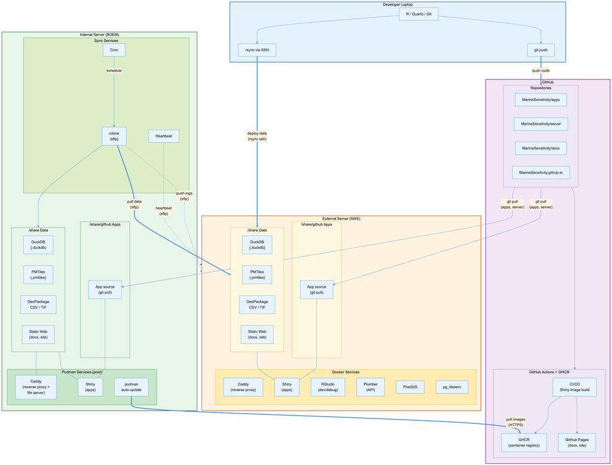

Figure 1: Overall server architecture showing developer laptop, GitHub (repos + container registry), external AWS server (Docker), and internal BOEM server (Podman) with container services and data flows.

### 2.1 Current state (external only)

The existing external server on AWS (`100.25.173.0`) runs the full development stack defined in [`docker-compose.yml`](https://github.com/MarineSensitivity/server/blob/main/docker-compose.yml):

| Service | Purpose | Port |
| --- | --- | --- |
| **caddy** | reverse proxy + TLS + file server | 80/443 |
| **rstudio** | development IDE + Shiny Server | 8787/3838 |
| **plumber** | R API | 8888 |
| **postgis** | PostgreSQL + PostGIS spatial database | 5432 |
| **pgadmin** | database admin UI | 8088 |
| **pgbkups** | automated database backups | — |
| **tile** | pg_tileserv (vector tiles from PostGIS) | 7800 |
| **tilecache** | Varnish cache for tile | 6081 |
| **titiler** | cloud-optimized GeoTIFF tile server | 8000 |
| **titilecache** | Varnish cache for titiler | 6082 |

The current deployment workflow uses two channels:

- **Data files** — the developer runs [`deploy_to_server.sh`](https://github.com/MarineSensitivity/workflows/blob/main/libs/deploy_to_server.sh), which uses `rsync` over SSH to push derived data (DuckDB, GeoPackage, CSV, TIF) from the developer laptop to the external server’s `/share/data` directory, then restarts the Shiny container.
- **App source code** — the developer pushes to [GitHub](https://github.com/MarineSensitivity/apps), then SSHs into the external server to run `git pull` in `/share/github/MarineSensitivity/apps`. The Shiny Server watches the app directories and picks up changes automatically.

Static web content is currently served via GitHub Pages:

- marinesensitivity.org — project homepage (MarineSensitivity.github.io)
- marinesensitivity.org/docs — project documentation (MarineSensitivity/docs)

### 2.2 Target state (internal production)

The internal BOEM server runs a minimal production stack defined in `prod/docker-compose.yml`:

| Service | Purpose | Port |
| --- | --- | --- |
| **caddy** | reverse proxy + file server + docs | 80 |
| **shiny** | R Shiny applications | 3838 |
| **auto-update** | automatic container image updates (podman) | — |

Services **not needed** on production:

- **rstudio** — development only; debugging happens on external server
- **postgis / pgadmin / pgbkups** — database migrated to DuckDB (file-based)
- **plumber** — API either proxied or migrated
- **tile / tilecache** — vector tiles migrated to PMTiles (file-based)
- **titiler / titilecache** — raster tiles served differently or proxied

The key architectural simplification is replacing the PostGIS + pg_tileserv stack with **PMTiles** (a single file format for vector tiles served directly by Caddy as static files) and replacing PostGIS-backed raster queries with **DuckDB** (an embedded analytical database read directly by Shiny apps).

## 3 Synchronization Overview

All synchronization is **initiated by the internal server** — it pulls updates from the external server and pushes logs back. No inbound connections to the BOEM network are required.

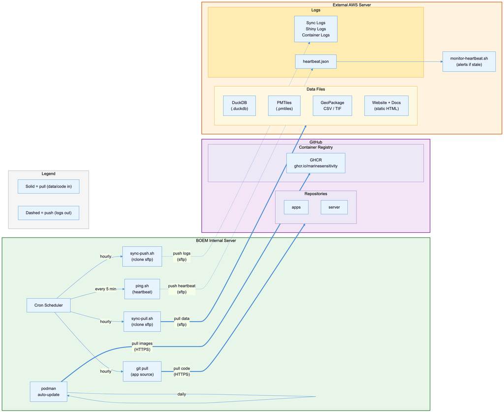

Figure 2: Synchronization flow between internal BOEM server, external AWS server, and GitHub. All connections are initiated by the internal server (outbound only).

### 3.1 Sync summary

| What | Direction | Source | Tool | Schedule | Protocol |
| --- | --- | --- | --- | --- | --- |
| Data files (duckdb, gpkg, csv, tif) | internal pulls | external server | rclone (sftp) | hourly | SSH |
| PMTiles | internal pulls | external server | rclone (sftp) | hourly | SSH |
| Static website/docs | internal pulls | external server | rclone (sftp) | hourly | SSH |
| Shiny app source | internal pulls | GitHub repos | git pull | hourly | HTTPS |
| Server config | internal pulls | GitHub repos | git pull | hourly | HTTPS |
| Container images | internal pulls | GitHub GHCR | podman auto-update | daily | HTTPS |
| Sync/Shiny/container logs | internal pushes | external server | rclone (sftp) | hourly | SSH |
| Heartbeat | internal pushes | external server | rclone (sftp) | every 5 min | SSH |

## 4 Implementation

### 4.1 Prerequisites

On the **internal BOEM server** (Red Hat Linux):

```bash
# install rclone
sudo yum install -y rclone

# install podman and podman-compose (RHEL 8)
sudo yum install -y podman podman-compose
sudo systemctl enable --now podman.socket

# create log directory
sudo mkdir -p /var/log/msens
sudo chown $USER:$USER /var/log/msens

# create data directories
sudo mkdir -p /share/data /share/public/www /share/github/MarineSensitivity /share/logs
```

### 4.2 SSH key setup

Generate an SSH key pair on the internal server for passwordless authentication to the external server:

```bash
# on internal server
ssh-keygen -t ed25519 -f ~/.ssh/msens_sync -N "" -C "msens-sync@boem"

# copy public key to external server (one-time manual step)
ssh-copy-id -i ~/.ssh/msens_sync.pub ubuntu@msens1.marinesensitivity.org
```

### 4.3 rclone configuration

Configure rclone on the internal server to connect to the external server via SFTP:

```bash
# create rclone config
rclone config

# or write directly:
cat >> ~/.config/rclone/rclone.conf <<'EOF'
[ext_dev]
type = sftp
host = msens1.marinesensitivity.org
user = ubuntu
key_file = /home/<user>/.ssh/msens_sync
shell_type = unix
EOF
```

Test the connection:

```bash
rclone lsd ext_dev:/share/data/derived/
```

### 4.4 Sync scripts

The sync scripts live in `prod/` and handle pulling data and pushing logs:

- **`prod/sync-pull.sh`** — pulls data files, PMTiles, static website, and Shiny apps from the external server
- **`prod/sync-push.sh`** — pushes sync logs, Shiny logs, and container logs to the external server for remote debugging
- **`prod/ping.sh`** — sends a heartbeat JSON with system health info every 5 minutes

Make scripts executable:

```bash
chmod +x prod/sync-pull.sh prod/sync-push.sh prod/ping.sh
```

### 4.5 Auto-update (podman auto-update)

Podman’s built-in [`auto-update`](https://docs.podman.io/en/latest/markdown/podman-auto-update.1.html) mechanism checks the container registry for newer images and restarts containers that have the `io.containers.autoupdate=registry` label. This replaces Watchtower (which requires Docker’s socket).

The shiny service in `prod/docker-compose.yml` already has the label set. Enable the systemd timer to run auto-update daily:

```bash
# enable the podman auto-update timer (checks daily)
sudo systemctl enable --now podman-auto-update.timer

# verify the timer is active
systemctl list-timers podman-auto-update.timer

# manual one-time check
podman auto-update
```

When the developer pushes a new Shiny image to GitHub Container Registry (GHCR), `podman auto-update` will detect the update on the next timer run, pull the new image, and restart the container.

### 4.6 Cron schedule

Add the following to the internal server’s crontab (`crontab -e`):

```
# marine sensitivity toolkit sync jobs
# pull data and content from external server (hourly at :05)
5 * * * * /share/github/server/prod/sync-pull.sh

# push logs to external server (hourly at :35)
35 * * * * /share/github/server/prod/sync-push.sh

# heartbeat ping (every 5 minutes)
*/5 * * * * /share/github/server/prod/ping.sh
```

### 4.7 Monitoring and alerting

The heartbeat strategy uses a push model — the internal server pushes a `heartbeat.json` file to the external server every 5 minutes. The external server runs a monitor script that checks the heartbeat age and sends email alerts if it goes stale.

On the **external server**, add to crontab:

```
# check internal server heartbeat (every 10 minutes)
*/10 * * * * /share/github/server/prod/monitor-heartbeat.sh
```

The heartbeat JSON includes:

```json
{
  "timestamp":    "2026-02-19T14:30:00Z",
  "hostname":     "boem-msens-prod",
  "uptime_since": "2026-02-01 08:00:00",
  "disk_free":    "142G",
  "mem_free":     "8.2G",
  "services": {
    "caddy": "running",
    "shiny": "running"
  }
}
```

If no heartbeat arrives for 15 minutes, the monitor sends an email alert with the last known service states.

## 5 Production Stack

The production container configuration (`prod/docker-compose.yml`, run with `podman-compose`) provides only the essential services:

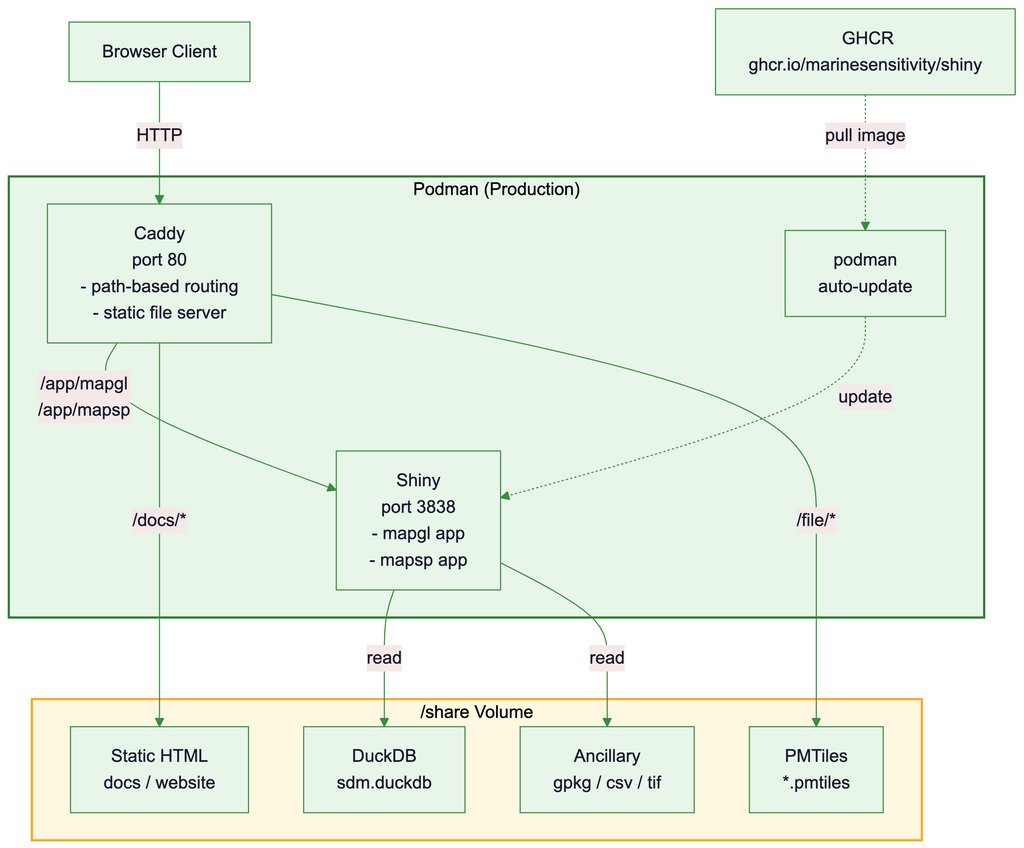

Figure 3: Production server Podman services and data flow. Caddy serves static content and proxies Shiny. Data files are mounted as volumes.

### 5.1 Container image build and distribution

The production Shiny image (`ghcr.io/marinesensitivity/shiny:latest`) is built from `prod/shiny/Dockerfile` and pushed to GitHub Container Registry (GHCR). A GitHub Actions workflow automatically builds and pushes the image when the Dockerfile changes on `main`. Manual builds can also be triggered via `workflow_dispatch`.

**When to rebuild**: only when R package dependencies change (adding/removing/upgrading packages). App code changes do **not** require an image rebuild — app source is mounted as a volume.

#### 5.1.1 First-time GHCR setup

Both `docker` (developer laptop) and `podman` (RHEL production server) produce OCI-compatible images — either can build/push to GHCR.

```bash
# authenticate to GHCR (docker on laptop, podman on production server)
cat ~'/My Drive/private/GITHUB_PAT_full-scope_2024-12-03_no-expiration.txt' | docker login ghcr.io -u bbest --password-stdin
```

After pushing the first image, set the GHCR package visibility to **Public** in the package settings at `https://github.com/orgs/MarineSensitivity/packages/container/shiny/settings`.

#### 5.1.2 Manual build and push (from developer laptop)

```bash
# build locally (docker on laptop)
docker build -t ghcr.io/marinesensitivity/shiny:latest ./prod/shiny

# push to GHCR
docker push ghcr.io/marinesensitivity/shiny:latest
```

#### 5.1.3 Pull on internal server

```bash
# pull the latest image
podman pull ghcr.io/marinesensitivity/shiny:latest

# restart with the new image
cd /share/github/MarineSensitivity/server/prod
podman-compose up -d
```

`podman auto-update` (Section 4.5) automates this — the systemd timer checks GHCR daily and pulls new images automatically.

#### 5.1.4 Offline fallback (save / load)

If the internal server cannot reach `ghcr.io`, transfer the image manually:

```bash
# on a machine with internet access (docker on laptop)
docker pull ghcr.io/marinesensitivity/shiny:latest
docker save ghcr.io/marinesensitivity/shiny:latest | gzip > shiny-latest.tar.gz

# transfer shiny-latest.tar.gz to internal server (e.g., via rclone, scp, USB)

# on internal server (podman)
gunzip -c shiny-latest.tar.gz | podman load
podman-compose up -d
```

### 5.2 Deployment

```bash
# clone repos on internal server
mkdir -p /share/github/MarineSensitivity
cd /share/github/MarineSensitivity
git clone https://github.com/MarineSensitivity/server.git
git clone https://github.com/MarineSensitivity/apps.git

# pull the shiny image from GHCR (first time)
podman pull ghcr.io/marinesensitivity/shiny:latest

# start services
cd server/prod
podman-compose up -d

# verify
podman ps
curl -s http://localhost/app/mapgl | head -5
```

The Shiny apps are mounted as a volume from the `apps` repo clone at `/share/github/MarineSensitivity/apps` into the Shiny container at `/srv/shiny-server`. This means app code updates only require a `git pull` in the apps repo — no image rebuild needed.

### 5.3 Migrating static web content

The project website and documentation currently served by GitHub Pages can be served internally by Caddy as static files:

| Content | Current URL | Internal URL | Internal path |
| --- | --- | --- | --- |
| Project homepage | marinesensitivity.org | ioemazeudmar01.mms.doi.net/ | /share/public/www/ |
| Project documentation | marinesensitivity.org/docs | ioemazeudmar01.mms.doi.net/docs/ | /share/public/www/docs/ |
| Composite Scores app | app.marinesensitivity.org/mapgl | ioemazeudmar01.mms.doi.net/app/mapgl | (Shiny container) |
| Species Distribution app | app.marinesensitivity.org/mapsp | ioemazeudmar01.mms.doi.net/app/mapsp | (Shiny container) |
| Public file server | file.marinesensitivity.org | ioemazeudmar01.mms.doi.net/file/ | /share/public/ |

The `sync-pull.sh` script automatically syncs these from the external server where they are built by GitHub Actions and deployed to `/share/public/www/`.

## 6 Government Compliance

This section reviews the relevant IT policy statutes and guidelines applicable to BOEM (Bureau of Ocean Energy Management), the Department of the Interior (DOI), and federal .gov requirements, and describes how the proposed synchronization arrangement is acceptable.

### 6.1 Federal Information Security Modernization Act (FISMA)

[FISMA](https://www.cisa.gov/topics/cyber-threats-and-advisories/federal-information-security-modernization-act) requires federal agencies to implement information security programs. The proposed arrangement is compliant because:

- **All connections are outbound from the BOEM network** — the internal server initiates all SSH/SFTP transfers to the external server. No inbound ports need to be opened on the BOEM firewall.
- **Data classification** — the MST data (species distribution models, sensitivity scores) is **publicly available scientific data** with no Controlled Unclassified Information (CUI) or Personally Identifiable Information (PII). All data will eventually be published openly.
- **Encryption in transit** — all transfers use SSH (SFTP) with Ed25519 key authentication, providing FIPS 140-2 compliant encryption.
- **Principle of least privilege** — the sync account on the external server has read-only access to data directories and write-only access to log directories.

### 6.2 NIST SP 800-53 (Security and Privacy Controls)

The [NIST 800-53](https://csrc.nist.gov/publications/detail/sp/800-53/rev-5/final) framework applies to DOI systems. Relevant control families:

| Control Family | Control | Compliance Approach |
| --- | --- | --- |
| **AC** (Access Control) | AC-3, AC-6 | SSH key-based auth, least privilege, no shared credentials |
| **AU** (Audit) | AU-2, AU-3 | All sync operations logged with timestamps; logs pushed to external for review |
| **CM** (Configuration Mgmt) | CM-2, CM-3 | Podman containers provide immutable, versioned configurations; `podman auto-update` only updates from trusted GHCR registry |
| **IA** (Identification & Auth) | IA-2, IA-5 | Ed25519 SSH keys (no passwords); keys stored with restricted permissions |
| **SC** (System & Comms Protection) | SC-8, SC-13 | All data in transit encrypted via SSH; TLS for HTTPS |
| **SI** (System & Info Integrity) | SI-2, SI-3 | Red Hat `yum` updates for OS patching; container images scanned upstream |

### 6.3 DOI Information Security Policy

The [DOI Departmental Manual Part 375](https://www.doi.gov/elips/browse) and [DOI Cybersecurity Program](https://www.doi.gov/ocio/policy-mgmt-support) require:

- **Authority to Operate (ATO)** — the internal server should be registered in the DOI System Inventory and receive an ATO. The low-risk nature of the data (public scientific information) supports a streamlined assessment.
- **Continuous monitoring** — the heartbeat mechanism and log synchronization provide continuous visibility into server health without requiring inbound network access.
- **Incident response** — if the external server is compromised, the internal server’s pull-only model limits exposure: it only reads data files and container images from trusted sources (GHCR, known SFTP endpoint).

### 6.4 FedRAMP and Cloud Services

The external development server runs on **AWS**, which holds a [FedRAMP](https://www.fedramp.gov/) authorization at the High impact level. This means:

- The cloud infrastructure meets federal security requirements
- AWS provides the physical and infrastructure security controls
- The MST application layer (containers, data files) operates within this authorized environment

### 6.5 Trusted Internet Connection (TIC) 3.0

[TIC 3.0](https://www.cisa.gov/resources-tools/programs/trusted-internet-connections-tic) guidance from CISA allows for more flexible network architectures than the original TIC model. The proposed arrangement:

- Uses **outbound-only connections** from the BOEM network, consistent with TIC guidance allowing authorized outbound traffic
- Does not require opening inbound ports or creating network exceptions
- SSH/SFTP traffic can be monitored by existing BOEM network security appliances (firewalls, IDS/IPS)

### 6.6 BOEM-Specific Considerations

- **Data sensitivity**: all MST data is **non-sensitive, publicly releasable** scientific information. Species distribution models, extinction risk scores, and sensitivity metrics are derived from publicly available datasets (AquaMaps, IUCN, NOAA, USFWS).
- **Contractor access**: the lead contractor maintains the external development server under the existing BOEM contract. Development artifacts are delivered to BOEM via the synchronization mechanism described here.
- **Open source**: all MST source code is published on [GitHub](https://github.com/MarineSensitivity) under MIT license, consistent with federal open-source policies ([M-16-21](https://obamawhitehouse.archives.gov/sites/default/files/omb/memoranda/2016/m_16_21.pdf), Federal Source Code Policy).

### 6.7 Compliance summary

| Requirement | Status | Notes |
| --- | --- | --- |
| FISMA compliance | Compliant | outbound-only connections, encrypted, public data |
| NIST 800-53 controls | Addressed | see control mapping above |
| DOI security policy | Requires ATO | low-risk system; streamlined assessment recommended |
| FedRAMP (external) | Compliant | AWS holds FedRAMP High authorization |
| TIC 3.0 | Compliant | outbound SSH/HTTPS only |
| Data classification | Low risk | public scientific data, no CUI/PII |
| Open source policy | Compliant | MIT-licensed on GitHub |

## 7 Issues

The following items require clarification or action before full deployment:

### 7.1 1. Operating system compatibility

The internal BOEM server runs **Red Hat Enterprise Linux 8** (RHEL 8) with `yum`-based package management, while the external development server runs **Ubuntu** with `apt`. This should **not be a concern** because:

- All application services run inside containers, which are OS-independent
- The internal server uses **podman** and **podman-compose** (included in RHEL 8); the external server uses Docker — both run OCI-compatible containers
- Only host-level tools differ: `rclone`, `podman`/`docker`, `cron` — all available on both platforms
- Container images built on Ubuntu will run identically on a RHEL host under podman
- OS updates (via `yum` on RHEL, `apt` on Ubuntu) are independent of the containerized services

**Action**: confirm RHEL 8 version and ensure podman and podman-compose are installed and running.

### 7.2 2. Internal web server access (firewall rules)

Firewall rules on the BOEM network may restrict server access to web content ports. To serve the MST applications internally:

- **Port 80 (HTTP)** needs to be open for inbound traffic from BOEM users (or at least the BOEM internal network). Port 443 is not required since we serve HTTP-only internally.
- On RHEL, this may involve `firewalld` (preferred) or `iptables`:

```bash
# firewalld (recommended on RHEL)
sudo firewall-cmd --permanent --add-service=http
sudo firewall-cmd --reload

# or iptables
sudo iptables -A INPUT -p tcp --dport 80 -j ACCEPT
sudo iptables-save
```

- **Internal DNS**: the server hostname `ioemazeudmar01.mms.doi.net` is already assigned by BOEM IT. All services are accessed via subdirectory paths on this hostname (e.g., `ioemazeudmar01.mms.doi.net/app/mapgl`).

**Action**: confirm port 80 is open for internal traffic on the BOEM network.

### 7.3 3. External access and domain management

The `marinesensitivity.org` domain is currently managed by the lead contractor through SquareSpace. Questions to resolve:

- **Keep marinesensitivity.org?** The domain is well-established and used in publications. Advantages: continuity, contractor can manage DNS. Disadvantages: not a .gov domain, may need to transition at contract end.
- **Use a BOEM.gov subdomain?** (e.g., `marinesensitivity.boem.gov` or `mst.boem.gov`). Advantages: clearly government-affiliated, managed by BOEM IT. Disadvantages: requires DOI IT approval, potential delays.
- **Hybrid approach?** Use `marinesensitivity.org` externally (public-facing, contractor-managed) and a `.boem.gov` subdomain internally. The internal server would serve the same content under both names.

**Action**: decide on domain strategy and coordinate with BOEM IT and SquareSpace as needed.

### 7.4 4. SSH outbound access from BOEM network

The synchronization depends on the internal server being able to make **outbound SSH connections** (port 22) to the external server. If the BOEM network restricts outbound SSH:

- Request a firewall exception for outbound SSH to the specific AWS IP (`100.25.173.0`)
- Alternative: use HTTPS-based sync (e.g., rclone with WebDAV or S3) if SSH is blocked
- Alternative: use an SSH tunnel over HTTPS (port 443) if only HTTPS outbound is allowed

**Action**: confirm outbound SSH (port 22) is permitted from the internal server to the external server IP.

### 7.5 5. Container registry access

`podman auto-update` needs **outbound HTTPS access** to GitHub Container Registry (`ghcr.io`) to pull the production Shiny image (`ghcr.io/marinesensitivity/shiny:latest`). If HTTPS to external registries is restricted:

- Request firewall exception for `ghcr.io` (IP ranges published by GitHub)
- Alternative: manually transfer container images via `podman save` / `podman load`:

```bash
# on a machine with internet access
podman pull ghcr.io/marinesensitivity/shiny:latest
podman save ghcr.io/marinesensitivity/shiny:latest | gzip > shiny-latest.tar.gz

# transfer to internal server (e.g., via rclone sftp, scp, or USB)

# on internal server
gunzip -c shiny-latest.tar.gz | podman load
```

See Section 5.1 for full build and distribution details.

**Action**: confirm outbound HTTPS to `ghcr.io` is permitted.

### 7.6 6. Data volume sizing

The MST data footprint should be estimated for disk provisioning on the internal server:

[output not shown]

**Action**: confirm `/share` volume has sufficient capacity (recommend 50+ GB for headroom).

### 7.7 7. Backup strategy for internal server

While the external server has automated PostgreSQL backups, the internal production server should also have a backup plan:

- DuckDB files can be backed up by the regular sync (authoritative copy is on external)
- Podman volumes (Caddy certificates, config) should be included in any BOEM-managed backup system
- The `/share` directory should be on redundant storage or included in enterprise backup

**Action**: coordinate with BOEM IT on backup integration.

### 7.8 8. Caddy TLS certificates on internal network

The production Caddyfile listens on `:80` (HTTP only) as the default. Since the internal server hostname (`ioemazeudmar01.mms.doi.net`) has no public DNS and is not internet-accessible, Caddy cannot use Let’s Encrypt for automatic TLS.

This is acceptable for an intranet-only server on the BOEM network. To upgrade to HTTPS in the future:

- Use Caddy’s [internal TLS](https://caddyserver.com/docs/caddyfile/directives/tls#internal) with a self-signed certificate (browsers will show a warning)
- Use a BOEM-managed internal CA certificate and configure Caddy’s `tls` directive to use it
- Change the Caddyfile to listen on a hostname instead of `:80` and provide the cert/key files

**Action**: no action needed for initial deployment (HTTP-only is the default). Revisit if BOEM provides an internal CA certificate for HTTPS.